# Healthcare Fraud Detection

### Author: Huizhe (Sunny) Zhu- hz2657

Medical charges vary widely by region and type of work and other factors. This project aims to claim a doctor who charges high a fraud. We need to conclude what is a fair comparison, by considering the type of medical work (DRG) and state,

The goal of this project is to construct features/variables to identify fraud.

dataset description: https://data.cms.gov/Medicare-Inpatient/National-Summary-of-Inpatient-Charge-Data-by-Medic/efwk-h4x3

## 0. load packages, import dataset

```python
import numpy as np
import pandas as pd
```

```python
df = pd.read_csv('inpatientCharges.csv')
```

**Variable description**

- DRG Definition: Classification system that groups similar clinical conditions (diagnoses) and the procedures furnished by the hospital during the stay.
- Total discharges: The number of discharges billed by the provider for inpatient hospital services. When you leave a hospital after treatment, you go through a process called hospital discharge.
- Average Covered Charges = Total Covered Charge Amount / Total Discharges, Total Covered Charge Amount = the sum of all covered charges, Covered Charges: Charges for covered services that your health plan paid for.
- Average Total Payments = Total Payments / Total Discharges, Payment is the amount a hospital actually receives for providing patient care. This is the actual amount paid to a hospital by consumers, insurers or governments.
- Average Medicare Payments = Medicare Payment Amount / Total Discharges, Medicare Payment Amount: The average amount that Medicare pays to the provider for Medicare's share of the MS-DRG.

```python
# sort values for provider id
df = df.sort_values('Provider Id', ascending = True)
df.head(5)
```

|  | DRG Definition | Provider Id | Provider Name | Provider Street Address | Provider City | Provider State | Provider Zip Code | Hospital Referral Region Description | Total Discharges | Average Covered Charges | Average Total Payments | Average Medicare Payments |
| --- | --- | --- | --- | --- | --- | --- | --- | --- | --- | --- | --- | --- |
| 0 | 039 - EXTRACRANIAL PROCEDURES W/O CC/MCC | 10001 | SOUTHEAST ALABAMA MEDICAL CENTER | 1108 ROSS CLARK CIRCLE | DOTHAN | AL | 36301 | AL - Dothan | 91 | $32963.07 | $5777.24 | $4763.73 |
| 63035 | 292 - HEART FAILURE & SHOCK W CC | 10001 | SOUTHEAST ALABAMA MEDICAL CENTER | 1108 ROSS CLARK CIRCLE | DOTHAN | AL | 36301 | AL - Dothan | 229 | $23352.07 | $6045.81 | $4916.71 |
| 147575 | 812 - RED BLOOD CELL DISORDERS W/O MCC | 10001 | SOUTHEAST ALABAMA MEDICAL CENTER | 1108 ROSS CLARK CIRCLE | DOTHAN | AL | 36301 | AL - Dothan | 59 | $19670.22 | $4487.89 | $3879.84 |
| 88326 | 330 - MAJOR SMALL & LARGE BOWEL PROCEDURES W CC | 10001 | SOUTHEAST ALABAMA MEDICAL CENTER | 1108 ROSS CLARK CIRCLE | DOTHAN | AL | 36301 | AL - Dothan | 47 | $60062.12 | $14427.68 | $13471.08 |
| 161291 | 948 - SIGNS & SYMPTOMS W/O MCC | 10001 | SOUTHEAST ALABAMA MEDICAL CENTER | 1108 ROSS CLARK CIRCLE | DOTHAN | AL | 36301 | AL - Dothan | 18 | $19081.72 | $3822.44 | $3319.33 |

## 1. EDA

```python
# 163065 columns, 12 rows
df.shape
```

```
(163065, 12)
```

```python
# examine columns
df.columns
```

```
Index(['DRG Definition', 'Provider Id', 'Provider Name',
       'Provider Street Address', 'Provider City', 'Provider State',
       'Provider Zip Code', 'Hospital Referral Region Description',
       ' Total Discharges ', ' Average Covered Charges ',
       ' Average Total Payments ', 'Average Medicare Payments'],
      dtype='object')
```

```python
# check data types
df.dtypes
```

```
DRG Definition                          object
Provider Id                              int64
Provider Name                           object
Provider Street Address                 object
Provider City                           object
Provider State                          object
Provider Zip Code                        int64
Hospital Referral Region Description    object
 Total Discharges                        int64
 Average Covered Charges                object
 Average Total Payments                 object
Average Medicare Payments               object
dtype: object
```

```python
# convert last three columns to float
df[df.columns[9:]] = df[df.columns[9:]].replace('[\$,]', '', regex=True).astype(float)

# rename column names
df.columns = ['DRG Definition', 'Provider Id', 'Provider Name',
       'Provider Street Address', 'Provider City', 'Provider State',
       'Provider Zip Code', 'Hospital Referral Region Description',
       'Total Discharges', 'Average Covered Charges',
       'Average Total Payments', 'Average Medicare Payments']
```

```python
# by using .info(), we can see there is no na value in the dataset
df.info()
```

```
<class 'pandas.core.frame.DataFrame'>
Int64Index: 163065 entries, 0 to 144651
Data columns (total 12 columns):
DRG Definition                          163065 non-null object
Provider Id                             163065 non-null int64
Provider Name                           163065 non-null object
Provider Street Address                 163065 non-null object
Provider City                           163065 non-null object
Provider State                          163065 non-null object
Provider Zip Code                       163065 non-null int64
Hospital Referral Region Description    163065 non-null object
Total Discharges                        163065 non-null int64
Average Covered Charges                 163065 non-null float64
Average Total Payments                  163065 non-null float64
Average Medicare Payments               163065 non-null float64
dtypes: float64(3), int64(3), object(6)
memory usage: 16.2+ MB
```

```python
# Here we can see the average and standard devition for average covered charged, average total payments, and average medicare payment
# we can see average covered charged is more than average total payments, which is more than average medicare payments
df.describe()
```

|  | Provider Id | Provider Zip Code | Total Discharges | Average Covered Charges | Average Total Payments | Average Medicare Payments |
| --- | --- | --- | --- | --- | --- | --- |
| count | 163065.000000 | 163065.000000 | 163065.000000 | 163065.000000 | 163065.000000 | 163065.000000 |
| mean | 255569.865428 | 47938.121908 | 42.776304 | 36133.954224 | 9707.473804 | 8494.490964 |
| std | 151563.671767 | 27854.323080 | 51.104042 | 35065.365931 | 7664.642598 | 7309.467261 |
| min | 10001.000000 | 1040.000000 | 11.000000 | 2459.400000 | 2673.000000 | 1148.900000 |
| 25% | 110092.000000 | 27261.000000 | 17.000000 | 15947.160000 | 5234.500000 | 4192.350000 |
| 50% | 250007.000000 | 44309.000000 | 27.000000 | 25245.820000 | 7214.100000 | 6158.460000 |
| 75% | 380075.000000 | 72901.000000 | 49.000000 | 43232.590000 | 11286.400000 | 10056.880000 |
| max | 670077.000000 | 99835.000000 | 3383.000000 | 929118.900000 | 156158.180000 | 154620.810000 |

### exploratory graph

Graph 1: average covered charged by state

From the graph we can tell california has the highest 'Average Covered Charges'

```python
# Average Covered Charges by State
import seaborn as sns
import matplotlib.pyplot as plt

a4_dims = (15.7, 8.27)   # default figure size
fig, ax = plt.subplots(figsize=a4_dims)

sns.set(style="whitegrid")
sns.boxenplot(x="Provider State", y="Average Covered Charges",
              color="b", scale="linear", data=df,ax=ax)
ax.set_title('Average Covered Payment Hospital Received by State')
```

[output not shown]

Graph 2: average total payment recieved by hospitals by state

From the graph we can tell New York and California has the highest 'Average Total Payment'

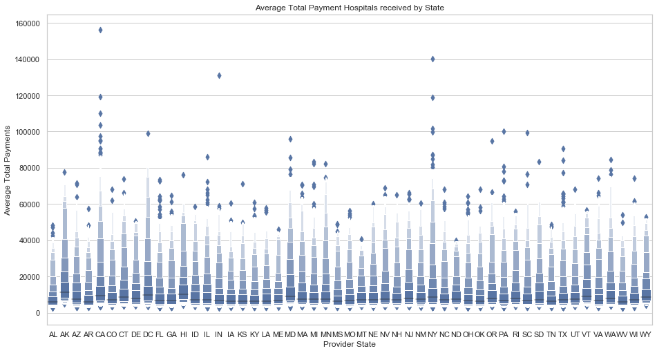

```python
a4_dims = (15.7, 8.27)   # default figure size
fig, ax = plt.subplots(figsize=a4_dims)

sns.set(style="whitegrid")
sns.boxenplot(x="Provider State",
              y="Average Total Payments",
              color="b", scale="linear", data=df,ax=ax)
ax.set_title('Average Total Payment Hospitals received by State')
```

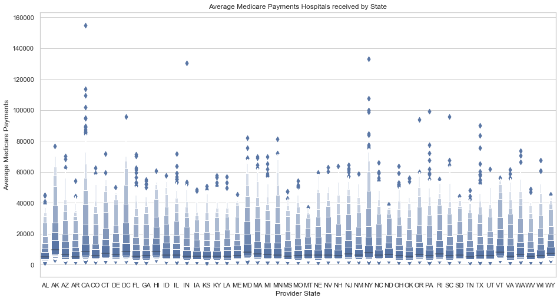

```python
a4_dims = (15.7, 8.27)   # default figure size
fig, ax = plt.subplots(figsize=a4_dims)

sns.set(style="whitegrid")
sns.boxenplot(x="Provider State",
              y="Average Medicare Payments",
              color="b", scale="linear", data=df, ax=ax)
ax.set_title('Average Medicare Payments Hospitals received by State')
```

# 2. construct features

we use aggregation strategy to generate features:

--- discharge by provider

1. total number of discharge by provider
- group by 'Provider Id', sum('Total Discharges')

--- ratio by clinical condition ----

--- ratio of discharge by city ----

1. ratio of total number of discharge by provider to the avergae level of discharges in the same city

### Feature 1. total number of discharge by provider

- group by 'Provider Id', sum('Total Discharges')

Why the feature can identify fraud:

- we can examine by selected city, which hospital has extreme number of total discharges. We can further examine the outliers.

```python
# create variable: discharge_by_provider
discharge_by_provider = df.groupby(['Provider Name', 'Provider Id', 'Provider City'])['Total Discharges'].sum()
discharge_by_provider = pd.DataFrame(discharge_by_provider)
discharge_by_provider.columns = ['discharge_by_provider']

df2 = pd.merge(df, discharge_by_provider, how='left', on=['Provider Name', 'Provider Id', 'Provider City'])
df2.head(5)
```

|  | DRG Definition | Provider Id | Provider Name | Provider Street Address | Provider City | Provider State | Provider Zip Code | Hospital Referral Region Description | Total Discharges | Average Covered Charges | Average Total Payments | Average Medicare Payments | discharge_by_provider |
| --- | --- | --- | --- | --- | --- | --- | --- | --- | --- | --- | --- | --- | --- |
| 0 | 039 - EXTRACRANIAL PROCEDURES W/O CC/MCC | 10001 | SOUTHEAST ALABAMA MEDICAL CENTER | 1108 ROSS CLARK CIRCLE | DOTHAN | AL | 36301 | AL - Dothan | 91 | 32963.07 | 5777.24 | 4763.73 | 5405 |
| 1 | 292 - HEART FAILURE & SHOCK W CC | 10001 | SOUTHEAST ALABAMA MEDICAL CENTER | 1108 ROSS CLARK CIRCLE | DOTHAN | AL | 36301 | AL - Dothan | 229 | 23352.07 | 6045.81 | 4916.71 | 5405 |
| 2 | 812 - RED BLOOD CELL DISORDERS W/O MCC | 10001 | SOUTHEAST ALABAMA MEDICAL CENTER | 1108 ROSS CLARK CIRCLE | DOTHAN | AL | 36301 | AL - Dothan | 59 | 19670.22 | 4487.89 | 3879.84 | 5405 |
| 3 | 330 - MAJOR SMALL & LARGE BOWEL PROCEDURES W CC | 10001 | SOUTHEAST ALABAMA MEDICAL CENTER | 1108 ROSS CLARK CIRCLE | DOTHAN | AL | 36301 | AL - Dothan | 47 | 60062.12 | 14427.68 | 13471.08 | 5405 |
| 4 | 948 - SIGNS & SYMPTOMS W/O MCC | 10001 | SOUTHEAST ALABAMA MEDICAL CENTER | 1108 ROSS CLARK CIRCLE | DOTHAN | AL | 36301 | AL - Dothan | 18 | 19081.72 | 3822.44 | 3319.33 | 5405 |

```python
# bring index to columns
discharge_by_provider = discharge_by_provider.reset_index()

# select city: NEW YORK
selected = discharge_by_provider.loc[discharge_by_provider['Provider City'] == 'NEW YORK']

# here we can see the total number of discharge by provider in New York
selected
```

|  | Provider Name | Provider Id | Provider City | discharge_by_provider |
| --- | --- | --- | --- | --- |
| 225 | BELLEVUE HOSPITAL CENTER | 330204 | NEW YORK | 1324 |
| 243 | BETH ISRAEL MEDICAL CENTER | 330169 | NEW YORK | 10395 |
| 1036 | HARLEM HOSPITAL CENTER | 330240 | NEW YORK | 630 |
| 1146 | HOSPITAL FOR SPECIAL SURGERY | 330270 | NEW YORK | 3956 |
| 1443 | LENOX HILL HOSPITAL | 330119 | NEW YORK | 5591 |
| 1769 | METROPOLITAN HOSPITAL CENTER | 330199 | NEW YORK | 447 |
| 1850 | MOUNT SINAI HOSPITAL | 330024 | NEW YORK | 10809 |
| 1902 | NEW YORK DOWNTOWN HOSPITAL | 330064 | NEW YORK | 1123 |
| 1906 | NEW YORK-PRESBYTERIAN HOSPITAL | 330101 | NEW YORK | 16834 |
| 2000 | NYU HOSPITALS CENTER | 330214 | NEW YORK | 6619 |
| 2777 | ST LUKE'S ROOSEVELT HOSPITAL | 330046 | NEW YORK | 6002 |

There are 11 providers in New York, from thh graph below we can see the number of discharges for each provider in NYC.

From the graph we can see, New York Presbyterian hospital has the most number of discharges.

```python
# data visualization
# select city = 'New York'
# x: Provider Name
# y: discharge_by_provider
import plotly
import plotly.express as px

fig = px.scatter(selected, x="Provider Name", y="discharge_by_provider",  color = 'discharge_by_provider', size = 'discharge_by_provider',
                 title = "Total number of discharge for providers in New York",
                  size_max=60,width=800, height=500)
fig.show()

#sns.set(style="whitegrid")
#sns.boxplot(x="Provider Name", y="discharge_by_provider",
           #    data=selected_df2)
```

[interactive chart not shown]

```python
# examine which city is included in the dataset
#for i in df2['Provider City'].unique():
#    print(i)
```

### Feature 2. ratio of average coverage by a provider / average coverage for this clinical condition in the state

- group by 'DRG Definition', 'Provider State', mean('Average Covered Charges')

Why the feature can identify fraud:

- we can examine by selected city, the ratio of average coverage for one clinical condition to the average of coverage for that clinical condition in the state

```python
# create variable: average_coverage_by_DRG_by_state
average_coverage_by_DRG_by_state = df2.groupby(['DRG Definition', 'Provider State'])['Average Covered Charges'].mean()

# create average spending group by agency and merchant category
average_coverage_by_DRG_by_state = pd.DataFrame(average_coverage_by_DRG_by_state)
average_coverage_by_DRG_by_state.columns = ['average_coverage_by_DRG_by_state']

# add the new feature average spending to the dataset
df2 = pd.merge(df2, average_coverage_by_DRG_by_state, how='left', on=['DRG Definition', 'Provider State'])
df2.head(5)

# Feature 2: ratio of amount spending and avergae spending by Description of transaction
df2['ratio_coverage_by_state'] = df2['Average Covered Charges'] / df2.average_coverage_by_DRG_by_state
df2.head(5)
```

|  | DRG Definition | Provider Id | Provider Name | Provider Street Address | Provider City | Provider State | Provider Zip Code | Hospital Referral Region Description | Total Discharges | Average Covered Charges | Average Total Payments | Average Medicare Payments | discharge_by_provider | average_coverage_by_DRG_by_state | ratio_coverage_by_state |
| --- | --- | --- | --- | --- | --- | --- | --- | --- | --- | --- | --- | --- | --- | --- | --- |
| 0 | 039 - EXTRACRANIAL PROCEDURES W/O CC/MCC | 10001 | SOUTHEAST ALABAMA MEDICAL CENTER | 1108 ROSS CLARK CIRCLE | DOTHAN | AL | 36301 | AL - Dothan | 91 | 32963.07 | 5777.24 | 4763.73 | 5405 | 32044.436957 | 1.028667 |
| 1 | 292 - HEART FAILURE & SHOCK W CC | 10001 | SOUTHEAST ALABAMA MEDICAL CENTER | 1108 ROSS CLARK CIRCLE | DOTHAN | AL | 36301 | AL - Dothan | 229 | 23352.07 | 6045.81 | 4916.71 | 5405 | 18605.193421 | 1.255137 |
| 2 | 812 - RED BLOOD CELL DISORDERS W/O MCC | 10001 | SOUTHEAST ALABAMA MEDICAL CENTER | 1108 ROSS CLARK CIRCLE | DOTHAN | AL | 36301 | AL - Dothan | 59 | 19670.22 | 4487.89 | 3879.84 | 5405 | 14831.877121 | 1.326212 |
| 3 | 330 - MAJOR SMALL & LARGE BOWEL PROCEDURES W CC | 10001 | SOUTHEAST ALABAMA MEDICAL CENTER | 1108 ROSS CLARK CIRCLE | DOTHAN | AL | 36301 | AL - Dothan | 47 | 60062.12 | 14427.68 | 13471.08 | 5405 | 63951.165429 | 0.939187 |
| 4 | 948 - SIGNS & SYMPTOMS W/O MCC | 10001 | SOUTHEAST ALABAMA MEDICAL CENTER | 1108 ROSS CLARK CIRCLE | DOTHAN | AL | 36301 | AL - Dothan | 18 | 19081.72 | 3822.44 | 3319.33 | 5405 | 15314.051957 | 1.246027 |

```python
# select DRG Definition = '039 - EXTRACRANIAL PROCEDURES W/O CC/MCC', city = 'New York'
selected1 = df2.loc[df2['Provider City'] == 'NEW YORK']
selected2 = selected1.loc[selected1['DRG Definition'] == '039 - EXTRACRANIAL PROCEDURES W/O CC/MCC']
selected2
```

|  | DRG Definition | Provider Id | Provider Name | Provider Street Address | Provider City | Provider State | Provider Zip Code | Hospital Referral Region Description | Total Discharges | Average Covered Charges | Average Total Payments | Average Medicare Payments | discharge_by_provider | average_coverage_by_DRG_by_state | ratio_coverage_by_state |
| --- | --- | --- | --- | --- | --- | --- | --- | --- | --- | --- | --- | --- | --- | --- | --- |
| 97836 | 039 - EXTRACRANIAL PROCEDURES W/O CC/MCC | 330024 | MOUNT SINAI HOSPITAL | ONE GUSTAVE L LEVY PLACE | NEW YORK | NY | 10029 | NY - Manhattan | 29 | 22169.41 | 11165.17 | 9504.37 | 10809 | 23260.677609 | 0.953085 |
| 99675 | 039 - EXTRACRANIAL PROCEDURES W/O CC/MCC | 330101 | NEW YORK-PRESBYTERIAN HOSPITAL | 525 EAST 68TH STREET | NEW YORK | NY | 10021 | NY - Manhattan | 49 | 32142.36 | 11869.00 | 9417.73 | 16834 | 23260.677609 | 1.381832 |
| 100223 | 039 - EXTRACRANIAL PROCEDURES W/O CC/MCC | 330119 | LENOX HILL HOSPITAL | 100 EAST 77TH STREET | NEW YORK | NY | 10021 | NY - Manhattan | 17 | 29515.52 | 8963.64 | 7907.64 | 5591 | 23260.677609 | 1.268902 |
| 101600 | 039 - EXTRACRANIAL PROCEDURES W/O CC/MCC | 330169 | BETH ISRAEL MEDICAL CENTER | FIRST AVENUE AT 16TH STREET | NEW YORK | NY | 10003 | NY - Manhattan | 17 | 31149.82 | 11056.88 | 10065.58 | 10395 | 23260.677609 | 1.339162 |
| 103095 | 039 - EXTRACRANIAL PROCEDURES W/O CC/MCC | 330214 | NYU HOSPITALS CENTER | 550 FIRST AVENUE | NEW YORK | NY | 10016 | NY - Manhattan | 33 | 37047.06 | 9422.84 | 8141.36 | 6619 | 23260.677609 | 1.592690 |

```python
fig = px.scatter(selected2, x="Provider Name", y="ratio_coverage_by_state",  color = 'ratio_coverage_by_state', size = 'ratio_coverage_by_state',
                 title = "Ratio of coverage for selected clinical condition to average level in New York",
                  size_max=60,width=800, height=500)
fig.show()
```

[interactive chart not shown]

### Feature 3. ratio of average total payment to a provider/ average payment for this clinical condition in the state

Why the feature can identify fraud:

- we can examine the actual payment to each provider in selected city for selected clinical condition, and identify outliers by the ratio.

```python
# create variable: average_coverage_by_DRG_by_state
average_payment_by_DRG_by_state = df2.groupby(['DRG Definition', 'Provider State'])['Average Total Payments'].mean()

# create average spending group by agency and merchant category
average_payment_by_DRG_by_state = pd.DataFrame(average_payment_by_DRG_by_state)
average_payment_by_DRG_by_state.columns = ['average_payment_by_DRG_by_state']

# add the new feature average spending to the dataset
df2 = pd.merge(df2, average_payment_by_DRG_by_state, how='left', on=['DRG Definition', 'Provider State'])

# Feature 2: ratio of amount spending and avergae spending by Description of transaction
df2['ratio_payment_by_state'] = df2['Average Total Payments'] / df2.average_payment_by_DRG_by_state
df2.head(5)
```

|  | DRG Definition | Provider Id | Provider Name | Provider Street Address | Provider City | Provider State | Provider Zip Code | Hospital Referral Region Description | Total Discharges | Average Covered Charges | Average Total Payments | Average Medicare Payments | discharge_by_provider | average_coverage_by_DRG_by_state | ratio_coverage_by_state | average_payment_by_DRG_by_state | ratio_payment_by_state |
| --- | --- | --- | --- | --- | --- | --- | --- | --- | --- | --- | --- | --- | --- | --- | --- | --- | --- |
| 0 | 039 - EXTRACRANIAL PROCEDURES W/O CC/MCC | 10001 | SOUTHEAST ALABAMA MEDICAL CENTER | 1108 ROSS CLARK CIRCLE | DOTHAN | AL | 36301 | AL - Dothan | 91 | 32963.07 | 5777.24 | 4763.73 | 5405 | 32044.436957 | 1.028667 | 5743.611739 | 1.005855 |
| 1 | 292 - HEART FAILURE & SHOCK W CC | 10001 | SOUTHEAST ALABAMA MEDICAL CENTER | 1108 ROSS CLARK CIRCLE | DOTHAN | AL | 36301 | AL - Dothan | 229 | 23352.07 | 6045.81 | 4916.71 | 5405 | 18605.193421 | 1.255137 | 5808.076974 | 1.040931 |
| 2 | 812 - RED BLOOD CELL DISORDERS W/O MCC | 10001 | SOUTHEAST ALABAMA MEDICAL CENTER | 1108 ROSS CLARK CIRCLE | DOTHAN | AL | 36301 | AL - Dothan | 59 | 19670.22 | 4487.89 | 3879.84 | 5405 | 14831.877121 | 1.326212 | 4652.981364 | 0.964519 |
| 3 | 330 - MAJOR SMALL & LARGE BOWEL PROCEDURES W CC | 10001 | SOUTHEAST ALABAMA MEDICAL CENTER | 1108 ROSS CLARK CIRCLE | DOTHAN | AL | 36301 | AL - Dothan | 47 | 60062.12 | 14427.68 | 13471.08 | 5405 | 63951.165429 | 0.939187 | 14706.072286 | 0.981070 |
| 4 | 948 - SIGNS & SYMPTOMS W/O MCC | 10001 | SOUTHEAST ALABAMA MEDICAL CENTER | 1108 ROSS CLARK CIRCLE | DOTHAN | AL | 36301 | AL - Dothan | 18 | 19081.72 | 3822.44 | 3319.33 | 5405 | 15314.051957 | 1.246027 | 3963.913261 | 0.964310 |

```python
# select DRG Definition = '039 - EXTRACRANIAL PROCEDURES W/O CC/MCC', city = 'New York'
selected1 = df2.loc[df2['Provider City'] == 'NEW YORK']
selected2 = selected1.loc[selected1['DRG Definition'] == '039 - EXTRACRANIAL PROCEDURES W/O CC/MCC']
selected2
```

|  | DRG Definition | Provider Id | Provider Name | Provider Street Address | Provider City | Provider State | Provider Zip Code | Hospital Referral Region Description | Total Discharges | Average Covered Charges | Average Total Payments | Average Medicare Payments | discharge_by_provider | average_coverage_by_DRG_by_state | ratio_coverage_by_state | average_payment_by_DRG_by_state | ratio_payment_by_state |
| --- | --- | --- | --- | --- | --- | --- | --- | --- | --- | --- | --- | --- | --- | --- | --- | --- | --- |
| 97836 | 039 - EXTRACRANIAL PROCEDURES W/O CC/MCC | 330024 | MOUNT SINAI HOSPITAL | ONE GUSTAVE L LEVY PLACE | NEW YORK | NY | 10029 | NY - Manhattan | 29 | 22169.41 | 11165.17 | 9504.37 | 10809 | 23260.677609 | 0.953085 | 8304.224565 | 1.344517 |
| 99675 | 039 - EXTRACRANIAL PROCEDURES W/O CC/MCC | 330101 | NEW YORK-PRESBYTERIAN HOSPITAL | 525 EAST 68TH STREET | NEW YORK | NY | 10021 | NY - Manhattan | 49 | 32142.36 | 11869.00 | 9417.73 | 16834 | 23260.677609 | 1.381832 | 8304.224565 | 1.429273 |
| 100223 | 039 - EXTRACRANIAL PROCEDURES W/O CC/MCC | 330119 | LENOX HILL HOSPITAL | 100 EAST 77TH STREET | NEW YORK | NY | 10021 | NY - Manhattan | 17 | 29515.52 | 8963.64 | 7907.64 | 5591 | 23260.677609 | 1.268902 | 8304.224565 | 1.079407 |
| 101600 | 039 - EXTRACRANIAL PROCEDURES W/O CC/MCC | 330169 | BETH ISRAEL MEDICAL CENTER | FIRST AVENUE AT 16TH STREET | NEW YORK | NY | 10003 | NY - Manhattan | 17 | 31149.82 | 11056.88 | 10065.58 | 10395 | 23260.677609 | 1.339162 | 8304.224565 | 1.331477 |
| 103095 | 039 - EXTRACRANIAL PROCEDURES W/O CC/MCC | 330214 | NYU HOSPITALS CENTER | 550 FIRST AVENUE | NEW YORK | NY | 10016 | NY - Manhattan | 33 | 37047.06 | 9422.84 | 8141.36 | 6619 | 23260.677609 | 1.592690 | 8304.224565 | 1.134704 |

There are 5 providers in New York provides '039 - EXTRACRANIAL PROCEDURES W/O CC/MCC' discharge.

From the graph below we can see New York Presbyterian hospital received approximately 1.5 times higher payment on the selected clinical condition compared to the average level in New York State.

```python
fig = px.scatter(selected2, x="Provider Name", y="ratio_payment_by_state",  color = 'ratio_payment_by_state', size = 'ratio_payment_by_state',
                 title = "Ratio of actual payment to hospital for selected clinical condition to average level in New York",
                  size_max=60,width=800, height=500)
fig.show()
```

[interactive chart not shown]

### Feature 4. ratio of average total medicard coverage paid to a provider/ average medicare coverage for this clinical condition in the state

Why the feature can identify fraud:

- we can examine which provider received most medicare payment, and examine the possibility of medicare fraud.

```python
# create variable: average_medicare_by_DRG_by_state
average_medicare_by_DRG_by_state = df2.groupby(['DRG Definition', 'Provider State'])['Average Medicare Payments'].mean()

# create average spending group by agency and merchant category
average_medicare_by_DRG_by_state = pd.DataFrame(average_medicare_by_DRG_by_state)
average_medicare_by_DRG_by_state.columns = ['average_medicare_by_DRG_by_state']

# add the new feature average spending to the dataset
df2 = pd.merge(df2, average_medicare_by_DRG_by_state, how='left', on=['DRG Definition', 'Provider State'])

# Feature 2: ratio of amount spending and avergae spending by Description of transaction
df2['ratio_medicare_by_state'] = df2['Average Medicare Payments'] / df2.average_medicare_by_DRG_by_state
df2.head(5)
```

|  | DRG Definition | Provider Id | Provider Name | Provider Street Address | Provider City | Provider State | Provider Zip Code | Hospital Referral Region Description | Total Discharges | Average Covered Charges | Average Total Payments | Average Medicare Payments | discharge_by_provider | average_coverage_by_DRG_by_state | ratio_coverage_by_state | average_payment_by_DRG_by_state | ratio_payment_by_state | average_medicare_by_DRG_by_state | ratio_medicare_by_state |
| --- | --- | --- | --- | --- | --- | --- | --- | --- | --- | --- | --- | --- | --- | --- | --- | --- | --- | --- | --- |
| 0 | 039 - EXTRACRANIAL PROCEDURES W/O CC/MCC | 10001 | SOUTHEAST ALABAMA MEDICAL CENTER | 1108 ROSS CLARK CIRCLE | DOTHAN | AL | 36301 | AL - Dothan | 91 | 32963.07 | 5777.24 | 4763.73 | 5405 | 32044.436957 | 1.028667 | 5743.611739 | 1.005855 | 4599.593043 | 1.035685 |
| 1 | 292 - HEART FAILURE & SHOCK W CC | 10001 | SOUTHEAST ALABAMA MEDICAL CENTER | 1108 ROSS CLARK CIRCLE | DOTHAN | AL | 36301 | AL - Dothan | 229 | 23352.07 | 6045.81 | 4916.71 | 5405 | 18605.193421 | 1.255137 | 5808.076974 | 1.040931 | 4950.631316 | 0.993148 |
| 2 | 812 - RED BLOOD CELL DISORDERS W/O MCC | 10001 | SOUTHEAST ALABAMA MEDICAL CENTER | 1108 ROSS CLARK CIRCLE | DOTHAN | AL | 36301 | AL - Dothan | 59 | 19670.22 | 4487.89 | 3879.84 | 5405 | 14831.877121 | 1.326212 | 4652.981364 | 0.964519 | 3738.925152 | 1.037689 |
| 3 | 330 - MAJOR SMALL & LARGE BOWEL PROCEDURES W CC | 10001 | SOUTHEAST ALABAMA MEDICAL CENTER | 1108 ROSS CLARK CIRCLE | DOTHAN | AL | 36301 | AL - Dothan | 47 | 60062.12 | 14427.68 | 13471.08 | 5405 | 63951.165429 | 0.939187 | 14706.072286 | 0.981070 | 12939.123429 | 1.041112 |
| 4 | 948 - SIGNS & SYMPTOMS W/O MCC | 10001 | SOUTHEAST ALABAMA MEDICAL CENTER | 1108 ROSS CLARK CIRCLE | DOTHAN | AL | 36301 | AL - Dothan | 18 | 19081.72 | 3822.44 | 3319.33 | 5405 | 15314.051957 | 1.246027 | 3963.913261 | 0.964310 | 3029.558261 | 1.095648 |

```python
# select DRG Definition = '039 - EXTRACRANIAL PROCEDURES W/O CC/MCC', city = 'New York'
selected1 = df2.loc[df2['Provider City'] == 'NEW YORK']
selected2 = selected1.loc[selected1['DRG Definition'] == '039 - EXTRACRANIAL PROCEDURES W/O CC/MCC']
selected2
```

|  | DRG Definition | Provider Id | Provider Name | Provider Street Address | Provider City | Provider State | Provider Zip Code | Hospital Referral Region Description | Total Discharges | Average Covered Charges | Average Total Payments | Average Medicare Payments | discharge_by_provider | average_coverage_by_DRG_by_state | ratio_coverage_by_state | average_payment_by_DRG_by_state | ratio_payment_by_state | average_medicare_by_DRG_by_state | ratio_medicare_by_state |
| --- | --- | --- | --- | --- | --- | --- | --- | --- | --- | --- | --- | --- | --- | --- | --- | --- | --- | --- | --- |
| 97836 | 039 - EXTRACRANIAL PROCEDURES W/O CC/MCC | 330024 | MOUNT SINAI HOSPITAL | ONE GUSTAVE L LEVY PLACE | NEW YORK | NY | 10029 | NY - Manhattan | 29 | 22169.41 | 11165.17 | 9504.37 | 10809 | 23260.677609 | 0.953085 | 8304.224565 | 1.344517 | 6796.218043 | 1.398479 |
| 99675 | 039 - EXTRACRANIAL PROCEDURES W/O CC/MCC | 330101 | NEW YORK-PRESBYTERIAN HOSPITAL | 525 EAST 68TH STREET | NEW YORK | NY | 10021 | NY - Manhattan | 49 | 32142.36 | 11869.00 | 9417.73 | 16834 | 23260.677609 | 1.381832 | 8304.224565 | 1.429273 | 6796.218043 | 1.385731 |
| 100223 | 039 - EXTRACRANIAL PROCEDURES W/O CC/MCC | 330119 | LENOX HILL HOSPITAL | 100 EAST 77TH STREET | NEW YORK | NY | 10021 | NY - Manhattan | 17 | 29515.52 | 8963.64 | 7907.64 | 5591 | 23260.677609 | 1.268902 | 8304.224565 | 1.079407 | 6796.218043 | 1.163535 |
| 101600 | 039 - EXTRACRANIAL PROCEDURES W/O CC/MCC | 330169 | BETH ISRAEL MEDICAL CENTER | FIRST AVENUE AT 16TH STREET | NEW YORK | NY | 10003 | NY - Manhattan | 17 | 31149.82 | 11056.88 | 10065.58 | 10395 | 23260.677609 | 1.339162 | 8304.224565 | 1.331477 | 6796.218043 | 1.481056 |
| 103095 | 039 - EXTRACRANIAL PROCEDURES W/O CC/MCC | 330214 | NYU HOSPITALS CENTER | 550 FIRST AVENUE | NEW YORK | NY | 10016 | NY - Manhattan | 33 | 37047.06 | 9422.84 | 8141.36 | 6619 | 23260.677609 | 1.592690 | 8304.224565 | 1.134704 | 6796.218043 | 1.197925 |

There are 5 providers in New York provides '039 - EXTRACRANIAL PROCEDURES W/O CC/MCC' discharge.

From the graph below we can see BETH ISREAL MEDICAL CENTER received approximately 1.5 times higher payment on the selected clinical condition compared to the average level in New York State, and it is the highest compared to other hospitals.

```python
fig = px.scatter(selected2, x="Provider Name", y="ratio_medicare_by_state",  color = 'ratio_medicare_by_state', size = 'ratio_medicare_by_state',
                 title = "Ratio of medicare payment to hospital for selected clinical condition to average level in New York",
                  size_max=60,width=800, height=500)
fig.show()
```

[interactive chart not shown]

### Feature 5. ratio of total number of discharge by provider to the avergae level of discharges in the same city

- group by 'Provider Id', 'Provider City' , sum('Total Discharges')

Why the feature can identify fraud:

- we can examine by selected city, which hospital has extreme number of total discharges. We can further examine the outliers.

```python
# create variable: average_medicare_by_DRG_by_state
average_discharge_by_provider_by_city = df2.groupby(['Provider Id', 'Provider City'])['Total Discharges'].mean()

# create average spending group by agency and merchant category
average_discharge_by_provider_by_city = pd.DataFrame(average_discharge_by_provider_by_city)
average_discharge_by_provider_by_city.columns = ['average_discharge_by_provider_by_city']

# add the new feature average spending to the dataset
df2 = pd.merge(df2, average_discharge_by_provider_by_city, how='left', on=['Provider Id', 'Provider City'])

# Feature 5
df2['ratio_average_discharge_by_provider_by_city'] = df2['Total Discharges'] / df2.average_discharge_by_provider_by_city
df2.head(2)
```

[output not shown]

```python
# select city = 'New York'
selected1 = df2.loc[df2['Provider City'] == 'NEW YORK']
selected1.head(2)
```

|  | DRG Definition | Provider Id | Provider Name | Provider Street Address | Provider City | Provider State | Provider Zip Code | Hospital Referral Region Description | Total Discharges | Average Covered Charges | ... | Average Medicare Payments | discharge_by_provider | average_coverage_by_DRG_by_state | ratio_coverage_by_state | average_payment_by_DRG_by_state | ratio_payment_by_state | average_medicare_by_DRG_by_state | ratio_medicare_by_state | average_discharge_by_provider_by_city | ratio_average_discharge_by_provider_by_city |
| --- | --- | --- | --- | --- | --- | --- | --- | --- | --- | --- | --- | --- | --- | --- | --- | --- | --- | --- | --- | --- | --- |
| 97829 | 189 - PULMONARY EDEMA & RESPIRATORY FAILURE | 330024 | MOUNT SINAI HOSPITAL | ONE GUSTAVE L LEVY PLACE | NEW YORK | NY | 10029 | NY - Manhattan | 34 | 28760.47 | ... | 14384.91 | 10809 | 31666.779099 | 0.908222 | 10670.750991 | 1.421960 | 9765.667117 | 1.473008 | 109.181818 | 0.311407 |
| 97830 | 390 - G.I. OBSTRUCTION W/O CC/MCC | 330024 | MOUNT SINAI HOSPITAL | ONE GUSTAVE L LEVY PLACE | NEW YORK | NY | 10029 | NY - Manhattan | 41 | 15255.97 | ... | 6599.14 | 10809 | 16825.411951 | 0.906722 | 5207.744512 | 1.471512 | 4048.090122 | 1.630186 | 109.181818 | 0.375520 |

2 rows × 21 columns

```python
fig = px.scatter(selected1, x="Provider Name", y="ratio_average_discharge_by_provider_by_city",  color = 'ratio_average_discharge_by_provider_by_city', size = 'ratio_average_discharge_by_provider_by_city',
                 title = "Ratio of total number of discharge by provider to the avergae level of discharges in New York",
                  size_max=60,width=900, height=600)
fig.show()
```

[interactive chart not shown]